# Ensemble Techniques - Term Deposit Subscription Prediction

Project 3 - (Term Deposit Sale)

#### Import all necessary libraries

```python
import numpy as np
import pandas as pd
import matplotlib.pyplot as plt
from sklearn.model_selection import train_test_split, cross_validate
from sklearn.preprocessing import StandardScaler,MinMaxScaler
from sklearn.linear_model import LogisticRegression
from sklearn.tree import DecisionTreeClassifier
from sklearn.metrics import f1_score,confusion_matrix,accuracy_score, precision_score,recall_score
import seaborn as sns
%matplotlib inline
```

```python
# import dataset
dataset = pd.read_csv("bank-full.csv")

dataset.head()
```

|  | age | job | marital | education | default | balance | housing | loan | contact | day | month | duration | campaign | pdays | previous | poutcome | Target |
| --- | --- | --- | --- | --- | --- | --- | --- | --- | --- | --- | --- | --- | --- | --- | --- | --- | --- |
| 0 | 58 | management | married | tertiary | no | 2143 | yes | no | unknown | 5 | may | 261 | 1 | -1 | 0 | unknown | no |
| 1 | 44 | technician | single | secondary | no | 29 | yes | no | unknown | 5 | may | 151 | 1 | -1 | 0 | unknown | no |
| 2 | 33 | entrepreneur | married | secondary | no | 2 | yes | yes | unknown | 5 | may | 76 | 1 | -1 | 0 | unknown | no |
| 3 | 47 | blue-collar | married | unknown | no | 1506 | yes | no | unknown | 5 | may | 92 | 1 | -1 | 0 | unknown | no |
| 4 | 33 | unknown | single | unknown | no | 1 | no | no | unknown | 5 | may | 198 | 1 | -1 | 0 | unknown | no |

## Deliverable – 1 (Exploratory data quality report reflecting the following) – (20)

1. Univariate analysis (12 marks) a. Univariate analysis – data types and description of the independent attributes

   ```
    which should include (name, meaning, range of values observed, central values
    (mean and median), standard deviation and quartiles, analysis of the body of
    distributions / tails, missing values, outliers.
   ```

   b. Strategies to address the different data challenges such as data pollution, outlier’s

   ```
    treatment and missing values treatment.
   ```

   c. Please provide comments in jupyter notebook regarding the steps you take and

   ```
    insights drawn from the plots.
   ```

2. Multivariate analysis (8 marks) a. Bi-variate analysis between the predictor variables and target column. Comment

   ```
    on your findings in terms of their relationship and degree of relation if any.
    Visualize the analysis using boxplots and pair plots, histograms or density curves.
    Select the most appropriate attributes.
   ```

   b. Please provide comments in jupyter notebook regarding the steps you take and

   ```
    insights drawn from the plots
   ```

## 1- Univariate analysis

```python
dataset.shape
```

```
(45211, 17)
```

```python
dataset.describe() # description for continues data
```

|  | age | balance | day | duration | campaign | pdays | previous |
| --- | --- | --- | --- | --- | --- | --- | --- |
| count | 45211.000000 | 45211.000000 | 45211.000000 | 45211.000000 | 45211.000000 | 45211.000000 | 45211.000000 |
| mean | 40.936210 | 1362.272058 | 15.806419 | 258.163080 | 2.763841 | 40.197828 | 0.580323 |
| std | 10.618762 | 3044.765829 | 8.322476 | 257.527812 | 3.098021 | 100.128746 | 2.303441 |
| min | 18.000000 | -8019.000000 | 1.000000 | 0.000000 | 1.000000 | -1.000000 | 0.000000 |
| 25% | 33.000000 | 72.000000 | 8.000000 | 103.000000 | 1.000000 | -1.000000 | 0.000000 |
| 50% | 39.000000 | 448.000000 | 16.000000 | 180.000000 | 2.000000 | -1.000000 | 0.000000 |
| 75% | 48.000000 | 1428.000000 | 21.000000 | 319.000000 | 3.000000 | -1.000000 | 0.000000 |
| max | 95.000000 | 102127.000000 | 31.000000 | 4918.000000 | 63.000000 | 871.000000 | 275.000000 |

```python
dataset.describe(include = [np.object])   # description for categorical data
```

|  | job | marital | education | default | housing | loan | contact | month | poutcome | Target |
| --- | --- | --- | --- | --- | --- | --- | --- | --- | --- | --- |
| count | 45211 | 45211 | 45211 | 45211 | 45211 | 45211 | 45211 | 45211 | 45211 | 45211 |
| unique | 12 | 3 | 4 | 2 | 2 | 2 | 3 | 12 | 4 | 2 |
| top | blue-collar | married | secondary | no | yes | no | cellular | may | unknown | no |
| freq | 9732 | 27214 | 23202 | 44396 | 25130 | 37967 | 29285 | 13766 | 36959 | 39922 |

```python
dataset.dtypes
```

```
age           int64
job          object
marital      object
education    object
default      object
balance       int64
housing      object
loan         object
contact      object
day           int64
month        object
duration      int64
campaign      int64
pdays         int64
previous      int64
poutcome     object
Target       object
dtype: object
```

### Analysis of the body of distributions

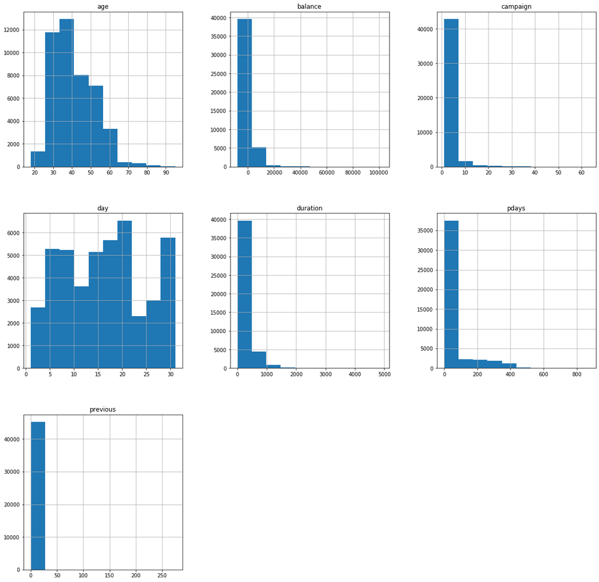

```python
dataset.hist(figsize=(20,20), column = list(dataset.columns))
plt.show()
```

### Check null values

```python
dataset.isna().sum()
```

```
age          0
job          0
marital      0
education    0
default      0
balance      0
housing      0
loan         0
contact      0
day          0
month        0
duration     0
campaign     0
pdays        0
previous     0
poutcome     0
Target       0
dtype: int64
```

- There are no null values in any of the column but there is Unknown

```python
for i in list(dataset.columns):
    print(dataset[i].value_counts())
```

```
32    2085
31    1996
33    1972
34    1930
35    1894
      ...
90       2
92       2
93       2
95       2
94       1
Name: age, Length: 77, dtype: int64
blue-collar      9732
management       9458
technician       7597
```

[output cut: 212 more lines]

### There are many columns with Unknown. For some columns number of unknown is higher than the other values count.

1. Drop the columns where frequent is Unknown
2. Impute the Unknown with frequent(mode) of the column

```python
# drop the poutcome column
dataset = dataset.drop(["poutcome"] , axis=1)

#replace Unknown with mode
dataset["contact"].replace(to_replace = ['unknown'] , value =dataset["contact"].mode() , inplace = True)
dataset["education"].replace(to_replace =['unknown'] , value =dataset["education"].mode() , inplace = True)
dataset["job"].replace(to_replace = ['unknown'] , value =dataset["job"].mode() , inplace = True)
```

```python
print (dataset["contact"].unique())
print (dataset["education"].unique())
print (dataset["job"].unique())
```

```
['cellular' 'telephone']
['tertiary' 'secondary' 'primary']
['management' 'technician' 'entrepreneur' 'blue-collar' 'retired' 'admin.'
 'services' 'self-employed' 'unemployed' 'housemaid' 'student']
```

### Outlier detection

```python
#shape before outlier removal
dataset.shape
```

```
(45211, 16)
```

```python
num_cols = dataset.describe().columns
Q1 = dataset[num_cols].quantile(0.05) # calculate the first quantile
Q3 = dataset[num_cols].quantile(0.95) # calculate the third quantile
IQR = Q3 - Q1 # interquartile range
dataset = dataset[~((dataset[num_cols] < (Q1 - 1.5 * IQR)) |(dataset[num_cols] > (Q3 + 1.5 * IQR))).any(axis=1)]
```

```python
#shape afater outlier removal
dataset.shape
```

```
(43836, 16)
```

## 2- Multivariate analysis (8 marks)

- a. Bi-variate analysis between the predictor variables and target column. Comment on your findings in terms of their relationship and degree of relation if any. Visualize the analysis using boxplots and pair plots, histograms or density curves.Select the most appropriate attributes.
- b. Please provide comments in jupyter notebook regarding the steps you take andinsights drawn from the plots

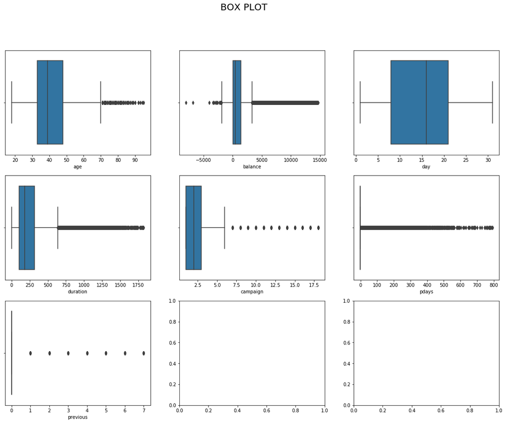

```python
#Boxplots
#box plot plot for each variable against label
column_names = list(dataset.describe().columns)
rows_s = int(len(column_names)/3)+1

f, axes = plt.subplots(rows_s, 3, figsize=(19,14), facecolor='white')
f.suptitle("BOX PLOT",size=20)

row = 0
column = 0
for i in column_names:
    ax = sns.boxplot(x=i, data=dataset , ax=axes[row,column])
    column+=1
    if column==3:
        column=0
        row+=1

plt.show()
```

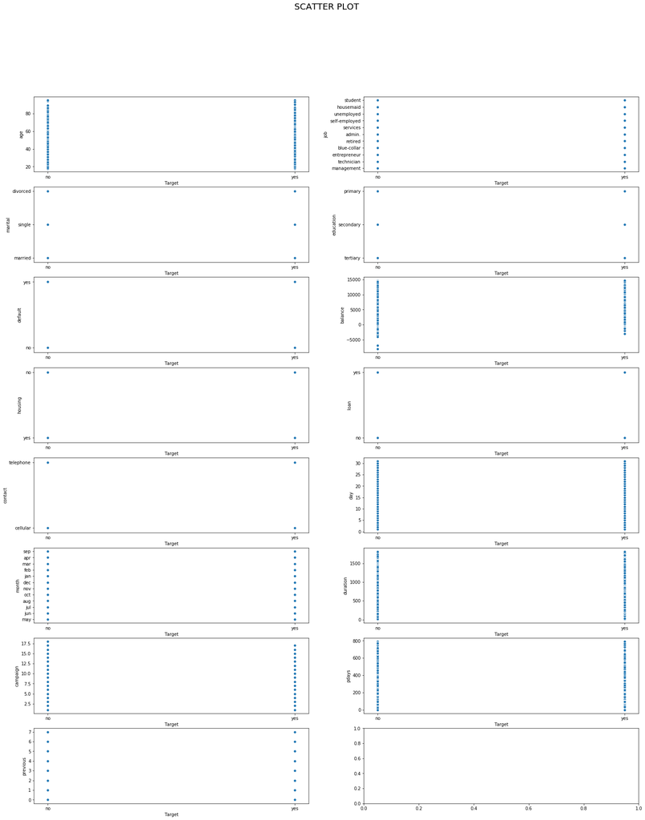

```python
#Scatter Plot
column_names = list(dataset.columns)
column_names.remove('Target')

rows_s = int(len(column_names)/2)+1

f, axes = plt.subplots(rows_s, 2, figsize=(25,30), facecolor='white')
f.suptitle("SCATTER PLOT",size=20)

row = 0
column = 0
for i in column_names:
    ax = sns.scatterplot(x='Target' , y=i, data=dataset , ax=axes[row,column])
    column+=1
    if column==2:
        column=0
        row+=1
plt.show()
```

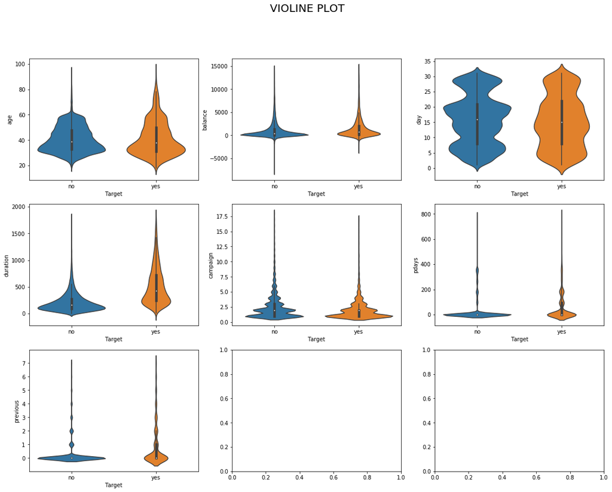

```python
#violine plot

column_names = list(dataset.describe().columns)
rows_s = int(len(column_names)/3)+1

f, axes = plt.subplots(rows_s, 3, figsize=(19,14), facecolor='white')
f.suptitle("VIOLINE PLOT",size=20)

row = 0
column = 0
for i in column_names:
    ax = sns.violinplot(x='Target', y=i, data=dataset , ax=axes[row,column])
    column+=1
    if column==3:
        column=0
        row+=1
plt.show()
```

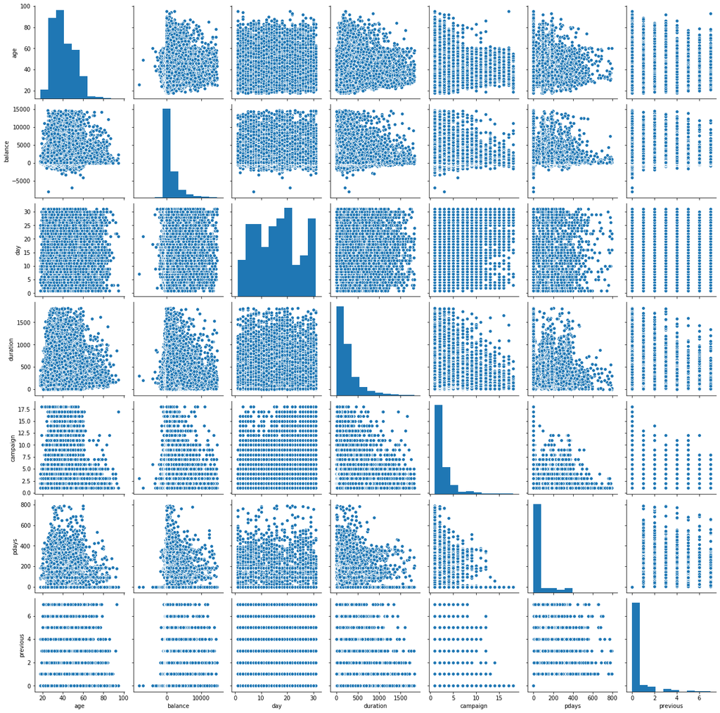

```python
sns.pairplot(dataset)
plt.show()
```

## Deliverable – 2 (Prepare the data for analytics) – (10)

- Ensure the attribute types are correct. If not, take appropriate actions.
- Get the data model ready.
- Transform the data i.e. scale / normalize if required
- Create the training set and test set in ratio of 70:30

### Label encode the categorical data

```python
from sklearn.preprocessing import LabelEncoder

cat_cols = dataset.describe(include = [np.object]).columns

encoders = []

for col in cat_cols:
    lbl = LabelEncoder()
    dataset.loc[:,col] = lbl.fit_transform(dataset[col])
    encoders.append(lbl)
```

### Normalize the numerical columns using MinMaxScaler

```python
from sklearn.preprocessing import MinMaxScaler

scalers = []

for col in num_cols:
    scaler = MinMaxScaler()
    dataset.loc[:,col] = scaler.fit_transform(np.array(dataset[col]).reshape(-1,1))
    scalers.append(scaler)
```

```python
Y = dataset["Target"]
X = dataset.drop("Target", axis = 1)
```

```python
X_train, X_test, y_train, y_test = train_test_split(X,Y,test_size=0.3 , random_state = 42)
```

```python
X
```

|  | age | job | marital | education | default | balance | housing | loan | contact | day | month | duration | campaign | pdays | previous |
| --- | --- | --- | --- | --- | --- | --- | --- | --- | --- | --- | --- | --- | --- | --- | --- |
| 0 | 0.519481 | 4 | 1 | 2 | 0 | 0.448139 | 1 | 0 | 0 | 0.133333 | 8 | 0.143171 | 0.000000 | 0.000000 | 0.000000 |
| 1 | 0.337662 | 9 | 2 | 1 | 0 | 0.354913 | 1 | 0 | 0 | 0.133333 | 8 | 0.082830 | 0.000000 | 0.000000 | 0.000000 |
| 2 | 0.194805 | 2 | 1 | 1 | 0 | 0.353722 | 1 | 1 | 0 | 0.133333 | 8 | 0.041690 | 0.000000 | 0.000000 | 0.000000 |
| 3 | 0.376623 | 1 | 1 | 1 | 0 | 0.420048 | 1 | 0 | 0 | 0.133333 | 8 | 0.050466 | 0.000000 | 0.000000 | 0.000000 |
| 4 | 0.194805 | 1 | 2 | 1 | 0 | 0.353678 | 0 | 0 | 0 | 0.133333 | 8 | 0.108612 | 0.000000 | 0.000000 | 0.000000 |
| 5 | 0.220779 | 4 | 1 | 2 | 0 | 0.363821 | 1 | 0 | 0 | 0.133333 | 8 | 0.076248 | 0.000000 | 0.000000 | 0.000000 |
| 6 | 0.129870 | 4 | 2 | 2 | 0 | 0.373346 | 1 | 1 | 0 | 0.133333 | 8 | 0.119035 | 0.000000 | 0.000000 | 0.000000 |
| 7 | 0.311688 | 2 | 0 | 2 | 1 | 0.353722 | 1 | 0 | 0 | 0.133333 | 8 | 0.208448 | 0.000000 | 0.000000 | 0.000000 |
| 8 | 0.519481 | 5 | 1 | 0 | 0 | 0.358970 | 1 | 0 | 0 | 0.133333 | 8 | 0.027427 | 0.000000 | 0.000000 | 0.000000 |
| 9 | 0.324675 | 9 | 2 | 1 | 0 | 0.379785 | 1 | 0 | 0 | 0.133333 | 8 | 0.030170 | 0.000000 | 0.000000 | 0.000000 |
| 10 | 0.298701 | 0 | 0 | 1 | 0 | 0.365541 | 1 | 0 | 0 | 0.133333 | 8 | 0.121777 | 0.000000 | 0.000000 | 0.000000 |
| 11 | 0.142857 | 0 | 2 | 1 | 0 | 0.370833 | 1 | 0 | 0 | 0.133333 | 8 | 0.075151 | 0.000000 | 0.000000 | 0.000000 |
| 12 | 0.454545 | 9 | 1 | 1 | 0 | 0.353898 | 1 | 0 | 0 | 0.133333 | 8 | 0.283598 | 0.000000 | 0.000000 | 0.000000 |
| 13 | 0.519481 | 9 | 1 | 1 | 0 | 0.356765 | 1 | 0 | 0 | 0.133333 | 8 | 0.038947 | 0.000000 | 0.000000 | 0.000000 |
| 14 | 0.506494 | 7 | 1 | 1 | 0 | 0.360778 | 1 | 0 | 0 | 0.133333 | 8 | 0.095447 | 0.000000 | 0.000000 | 0.000000 |
| 15 | 0.428571 | 5 | 1 | 0 | 0 | 0.363733 | 1 | 0 | 0 | 0.133333 | 8 | 0.193637 | 0.000000 | 0.000000 | 0.000000 |
| 16 | 0.350649 | 0 | 2 | 1 | 0 | 0.354207 | 1 | 0 | 0 | 0.133333 | 8 | 0.053758 | 0.000000 | 0.000000 | 0.000000 |
| 17 | 0.506494 | 1 | 1 | 0 | 0 | 0.355927 | 1 | 0 | 0 | 0.133333 | 8 | 0.020845 | 0.000000 | 0.000000 | 0.000000 |
| 18 | 0.545455 | 5 | 1 | 0 | 0 | 0.356280 | 1 | 0 | 0 | 0.133333 | 8 | 0.120132 | 0.000000 | 0.000000 | 0.000000 |
| 19 | 0.194805 | 7 | 1 | 1 | 0 | 0.353634 | 1 | 0 | 0 | 0.133333 | 8 | 0.029622 | 0.000000 | 0.000000 | 0.000000 |
| 20 | 0.129870 | 1 | 1 | 1 | 0 | 0.385518 | 1 | 1 | 0 | 0.133333 | 8 | 0.143719 | 0.000000 | 0.000000 | 0.000000 |
| 21 | 0.493506 | 4 | 1 | 2 | 0 | 0.387987 | 1 | 0 | 0 | 0.133333 | 8 | 0.089962 | 0.000000 | 0.000000 | 0.000000 |
| 22 | 0.181818 | 1 | 2 | 0 | 0 | 0.354648 | 1 | 1 | 0 | 0.133333 | 8 | 0.087767 | 0.000000 | 0.000000 | 0.000000 |
| 23 | 0.090909 | 7 | 1 | 1 | 0 | 0.355839 | 1 | 0 | 0 | 0.133333 | 8 | 0.187603 | 0.000000 | 0.000000 | 0.000000 |
| 24 | 0.285714 | 5 | 1 | 0 | 0 | 0.353634 | 1 | 1 | 0 | 0.133333 | 8 | 0.099287 | 0.000000 | 0.000000 | 0.000000 |
| 25 | 0.337662 | 0 | 1 | 1 | 0 | 0.337229 | 1 | 0 | 0 | 0.133333 | 8 | 0.094350 | 0.000000 | 0.000000 | 0.000000 |
| 26 | 0.272727 | 4 | 2 | 2 | 0 | 0.364879 | 1 | 0 | 0 | 0.133333 | 8 | 0.162370 | 0.000000 | 0.000000 | 0.000000 |
| 27 | 0.441558 | 2 | 1 | 1 | 0 | 0.358617 | 1 | 1 | 0 | 0.133333 | 8 | 0.069665 | 0.000000 | 0.000000 | 0.000000 |
| 28 | 0.363636 | 4 | 2 | 1 | 0 | 0.342785 | 1 | 0 | 0 | 0.133333 | 8 | 0.139879 | 0.058824 | 0.000000 | 0.000000 |
| 29 | 0.233766 | 9 | 2 | 1 | 0 | 0.365320 | 1 | 1 | 0 | 0.133333 | 8 | 0.190894 | 0.000000 | 0.000000 | 0.000000 |
| ... | ... | ... | ... | ... | ... | ... | ... | ... | ... | ... | ... | ... | ... | ... | ... |
| 45178 | 0.207792 | 1 | 1 | 1 | 0 | 0.367746 | 1 | 0 | 0 | 0.366667 | 9 | 0.226550 | 0.000000 | 0.117276 | 0.428571 |
| 45179 | 0.207792 | 9 | 1 | 1 | 0 | 0.398880 | 0 | 0 | 0 | 0.366667 | 9 | 0.174986 | 0.000000 | 0.127364 | 0.857143 |
| 45180 | 0.623377 | 5 | 1 | 1 | 0 | 0.503969 | 0 | 0 | 0 | 0.466667 | 9 | 0.227098 | 0.058824 | 0.035309 | 0.857143 |
| 45181 | 0.363636 | 1 | 1 | 1 | 0 | 0.656994 | 0 | 0 | 0 | 0.466667 | 9 | 0.040592 | 0.058824 | 0.150063 | 0.428571 |
| 45182 | 0.207792 | 9 | 1 | 1 | 0 | 0.359499 | 0 | 0 | 0 | 0.466667 | 9 | 0.219967 | 0.058824 | 0.237074 | 0.714286 |
| 45183 | 0.675325 | 5 | 1 | 0 | 0 | 0.367922 | 0 | 0 | 0 | 0.466667 | 9 | 0.042787 | 0.000000 | 0.122320 | 1.000000 |
| 45184 | 0.584416 | 5 | 1 | 1 | 0 | 0.419563 | 0 | 0 | 0 | 0.500000 | 9 | 0.075699 | 0.000000 | 0.029004 | 0.714286 |
| 45185 | 0.545455 | 7 | 1 | 2 | 0 | 0.541321 | 1 | 0 | 0 | 0.500000 | 9 | 0.109709 | 0.000000 | 0.117276 | 0.571429 |
| 45186 | 0.532468 | 1 | 1 | 1 | 0 | 0.419783 | 0 | 0 | 0 | 0.500000 | 9 | 0.153593 | 0.000000 | 0.132409 | 0.285714 |
| 45187 | 0.181818 | 7 | 2 | 1 | 0 | 0.405142 | 1 | 0 | 0 | 0.500000 | 9 | 0.225453 | 0.000000 | 0.000000 | 0.000000 |
| 45188 | 0.142857 | 4 | 2 | 1 | 0 | 0.384636 | 1 | 0 | 0 | 0.500000 | 9 | 0.129457 | 0.000000 | 0.694830 | 0.285714 |
| 45189 | 0.090909 | 7 | 2 | 1 | 0 | 0.362410 | 0 | 0 | 0 | 0.500000 | 9 | 0.094899 | 0.000000 | 0.117276 | 0.714286 |
| 45190 | 0.181818 | 1 | 1 | 1 | 0 | 0.359631 | 0 | 0 | 0 | 0.500000 | 9 | 0.113001 | 0.000000 | 0.238335 | 0.428571 |
| 45191 | 0.740260 | 5 | 0 | 2 | 0 | 0.521653 | 1 | 0 | 0 | 0.500000 | 9 | 0.143719 | 0.000000 | 0.232030 | 0.142857 |
| 45192 | 0.142857 | 4 | 2 | 2 | 0 | 0.387370 | 0 | 0 | 0 | 0.500000 | 9 | 0.130554 | 0.000000 | 0.000000 | 0.000000 |
| 45193 | 0.129870 | 6 | 2 | 2 | 0 | 0.360646 | 0 | 0 | 0 | 0.500000 | 9 | 0.246297 | 0.058824 | 0.042875 | 0.571429 |
| 45194 | 0.532468 | 4 | 1 | 2 | 0 | 0.359720 | 1 | 1 | 0 | 0.500000 | 9 | 0.088865 | 0.058824 | 0.237074 | 0.714286 |
| 45195 | 0.649351 | 5 | 1 | 1 | 0 | 0.404172 | 0 | 0 | 0 | 0.500000 | 9 | 0.116292 | 0.000000 | 0.237074 | 0.857143 |
| 45196 | 0.090909 | 8 | 2 | 1 | 0 | 0.369421 | 0 | 0 | 0 | 0.500000 | 9 | 0.181020 | 0.000000 | 0.000000 | 0.000000 |
| 45197 | 0.233766 | 4 | 2 | 1 | 0 | 0.420268 | 1 | 0 | 0 | 0.500000 | 9 | 0.148108 | 0.000000 | 0.000000 | 0.000000 |
| 45198 | 0.246753 | 4 | 1 | 2 | 0 | 0.416608 | 0 | 0 | 0 | 0.500000 | 9 | 0.182666 | 0.058824 | 0.000000 | 0.000000 |
| 45200 | 0.259740 | 9 | 1 | 1 | 0 | 0.378197 | 1 | 0 | 0 | 0.500000 | 9 | 0.853538 | 0.176471 | 0.000000 | 0.000000 |
| 45201 | 0.454545 | 4 | 1 | 2 | 0 | 0.379344 | 0 | 0 | 0 | 0.533333 | 9 | 0.123971 | 0.000000 | 0.233291 | 0.571429 |
| 45202 | 0.207792 | 0 | 2 | 1 | 0 | 0.378197 | 0 | 0 | 0 | 0.533333 | 9 | 0.122874 | 0.000000 | 0.000000 | 0.000000 |
| 45203 | 0.064935 | 8 | 2 | 2 | 0 | 0.358617 | 0 | 0 | 0 | 0.533333 | 9 | 0.145913 | 0.000000 | 0.000000 | 0.000000 |
| 45205 | 0.090909 | 9 | 2 | 1 | 0 | 0.375904 | 0 | 1 | 0 | 0.533333 | 9 | 0.211739 | 0.058824 | 0.000000 | 0.000000 |
| 45206 | 0.428571 | 9 | 1 | 2 | 0 | 0.390016 | 0 | 0 | 0 | 0.533333 | 9 | 0.535930 | 0.117647 | 0.000000 | 0.000000 |
| 45207 | 0.688312 | 5 | 0 | 0 | 0 | 0.429882 | 0 | 0 | 0 | 0.533333 | 9 | 0.250137 | 0.058824 | 0.000000 | 0.000000 |
| 45208 | 0.701299 | 5 | 1 | 1 | 0 | 0.605662 | 0 | 0 | 0 | 0.533333 | 9 | 0.618212 | 0.235294 | 0.233291 | 0.428571 |
| 45209 | 0.506494 | 1 | 1 | 1 | 0 | 0.383092 | 0 | 0 | 1 | 0.533333 | 9 | 0.278662 | 0.176471 | 0.000000 | 0.000000 |

43836 rows × 15 columns

## Deliverable – 3 (create the ensemble model) – (30)

- 1. First create models using Logistic Regression and Decision Tree algorithm. Note the model performance by using different matrices. Use confusion matrix to evaluate class level metrics i.e. Precision/Recall. Also reflect the accuracy and F1 score of the model. (10 marks)
- 1. Build the ensemble models (Bagging and Boosting) and note the model performance by using different matrices. Use same metrics as in above model. (at least 3 algorithms) (15 marks)

### Modelling

```python
model_result = []

def model_function(model,name, X_train, y_train , X_test , y_test):
    model.fit(X_train, y_train)
    pred = model.predict(X_test)

    f1 = f1_score(y_test, pred )
    ac = accuracy_score(y_test, pred )
    prec = precision_score(y_test, pred )
    rec = recall_score(y_test, pred )

    print ("F1 Score test score : ",f1)
    print ("Accuracy test score : ",ac)
    print ("Precision test score : ",prec)
    print ("Recall test score : ",rec)
    print ("Confusion Matrix : ")
    print (confusion_matrix(y_test, pred))

    print ()

    model_result.append(pd.DataFrame({
                        "Model" : [name] ,
                        "Test Accuracy" : ac,
                        "Test F1" : f1,
                        "Test Precision" :prec  ,
                        "Test Recall" : rec
                        }))
```

### Logistic Regression

```python
model = LogisticRegression(penalty="l2")
model_function(model,"LogisticRegression" ,X_train, y_train , X_test , y_test )
```

```
F1 Score test score :  0.3196029776674938
Accuracy test score :  0.8957493726712797
Precision test score :  0.602996254681648
Recall test score :  0.2174206617150574
Confusion Matrix :
[[11458   212]
 [ 1159   322]]
```

### Decision Tree Classifier

```python
model = DecisionTreeClassifier()

model_function(model,"DecisionTreeClassifier",X_train, y_train , X_test , y_test )
```

```
F1 Score test score :  0.4144562334217507
Accuracy test score :  0.8657136339441868
Precision test score :  0.40716612377850164
Recall test score :  0.4220121539500338
Confusion Matrix :
[[10760   910]
 [  856   625]]
```

### Ensemble models

```python
from sklearn.ensemble import RandomForestClassifier,GradientBoostingClassifier, AdaBoostClassifier
import xgboost as xgb
```

[output not shown]

### Random Forest Classifier

```python
rf = RandomForestClassifier(n_estimators=1000)
model_function(rf,"RandomForestClassifier",X_train, y_train , X_test , y_test )
```

```
F1 Score test score :  0.4517543859649123
Accuracy test score :  0.9049501939016045
Precision test score :  0.6445556946182729
Recall test score :  0.3477380148548278
Confusion Matrix :
[[11386   284]
 [  966   515]]
```

### Gradient Boosting Classifier

```python
gbc = GradientBoostingClassifier(n_estimators = 1000)
model_function(gbc,"GradientBoostingClassifier" , X_train, y_train , X_test , y_test )
```

```
F1 Score test score :  0.517921868707209
Accuracy test score :  0.9089803056801764
Precision test score :  0.6417165668662674
Recall test score :  0.43416610398379474
Confusion Matrix :
[[11311   359]
 [  838   643]]
```

### XGBoost

```python
xgb = xgboost.XGBClassifier(n_estimators=1000)
model_function(xgb,"XGBClassifier",X_train, y_train , X_test , y_test )
```

[output not shown]

### Score Comparison

```python
pd.concat(model_result)
```

[output not shown]